# Course_Project

suveyda

February 15, 2017

# Course Project

## Regression Models by Johns Hopkins University

### Introduction

This project is performed for a magazine about the automobile industry called “Motor Trend”. We will analyze the **Motor Trend Car Road Tests** data from R datasets package. It contains a data set of a collection of cars, and we are interested in exploring the relationship between a set of variables and miles per gallon (MPG). We are particularly interested in the following two questions:

- “Is an automatic or manual transmission better for MPG”
- “Quantify the MPG difference between automatic and manual transmissions”

### Data

The data was extracted from the 1974 Motor Trend US magazine, and comprises fuel consumption and 10 aspects of automobile design and performance for 32 automobiles (1973-74 models).

Dataset contains 32 observations on 11 variables:

- **mpg:** Miles/(US) gallon
- **cyl:** Number of cylinders
- **disp:** Displacement (cu.in.)
- **hp:** Gross horsepower
- **drat:** Rear axle ratio
- **wt:** Weight (1000 lbs)
- **qsec:** 1/4 mile time
- **vs:** V/S
- **am:** Transmission (0 = automatic, 1 = manual)
- **gear:** Number of forward gears
- **carb:** Number of carburetors

So, we first load the mtcars data to R, and take a look at the variables:

```r
data(mtcars)
mtcars$am <- as.factor(mtcars$am)
mtcars$cyl <- as.factor(mtcars$cyl)
mtcars$vs <- as.factor(mtcars$vs)
mtcars$gear <- as.factor(mtcars$gear)
mtcars$carb <- as.factor(mtcars$carb)
str(mtcars)
```

```
## 'data.frame':    32 obs. of  11 variables:
##  $ mpg : num  21 21 22.8 21.4 18.7 18.1 14.3 24.4 22.8 19.2 ...
##  $ cyl : Factor w/ 3 levels "4","6","8": 2 2 1 2 3 2 3 1 1 2 ...
##  $ disp: num  160 160 108 258 360 ...
##  $ hp  : num  110 110 93 110 175 105 245 62 95 123 ...
##  $ drat: num  3.9 3.9 3.85 3.08 3.15 2.76 3.21 3.69 3.92 3.92 ...
##  $ wt  : num  2.62 2.88 2.32 3.21 3.44 ...
##  $ qsec: num  16.5 17 18.6 19.4 17 ...
##  $ vs  : Factor w/ 2 levels "0","1": 1 1 2 2 1 2 1 2 2 2 ...
##  $ am  : Factor w/ 2 levels "0","1": 2 2 2 1 1 1 1 1 1 1 ...
##  $ gear: Factor w/ 3 levels "3","4","5": 2 2 2 1 1 1 1 2 2 2 ...
##  $ carb: Factor w/ 6 levels "1","2","3","4",..: 4 4 1 1 2 1 4 2 2 4 ...
```

### Exploratory Data Analyses

At this step, we perform some basic exploratory data analyses:

```r
summary(mtcars)
```

```
##       mpg        cyl         disp             hp             drat
##  Min.   :10.40   4:11   Min.   : 71.1   Min.   : 52.0   Min.   :2.760
##  1st Qu.:15.43   6: 7   1st Qu.:120.8   1st Qu.: 96.5   1st Qu.:3.080
##  Median :19.20   8:14   Median :196.3   Median :123.0   Median :3.695
##  Mean   :20.09          Mean   :230.7   Mean   :146.7   Mean   :3.597
##  3rd Qu.:22.80          3rd Qu.:326.0   3rd Qu.:180.0   3rd Qu.:3.920
##  Max.   :33.90          Max.   :472.0   Max.   :335.0   Max.   :4.930
##        wt             qsec       vs     am     gear   carb
##  Min.   :1.513   Min.   :14.50   0:18   0:19   3:15   1: 7
##  1st Qu.:2.581   1st Qu.:16.89   1:14   1:13   4:12   2:10
##  Median :3.325   Median :17.71                 5: 5   3: 3
##  Mean   :3.217   Mean   :17.85                        4:10
##  3rd Qu.:3.610   3rd Qu.:18.90                        6: 1
##  Max.   :5.424   Max.   :22.90                        8: 1
```

```r
table(mtcars$am)
```

```
##
##  0  1
## 19 13
```

According to the above table, we have 19 automatic and 13 manual transmission cars in the dataset. Furthermore, in the below plot you can see the distribution of mpg in the dataset:

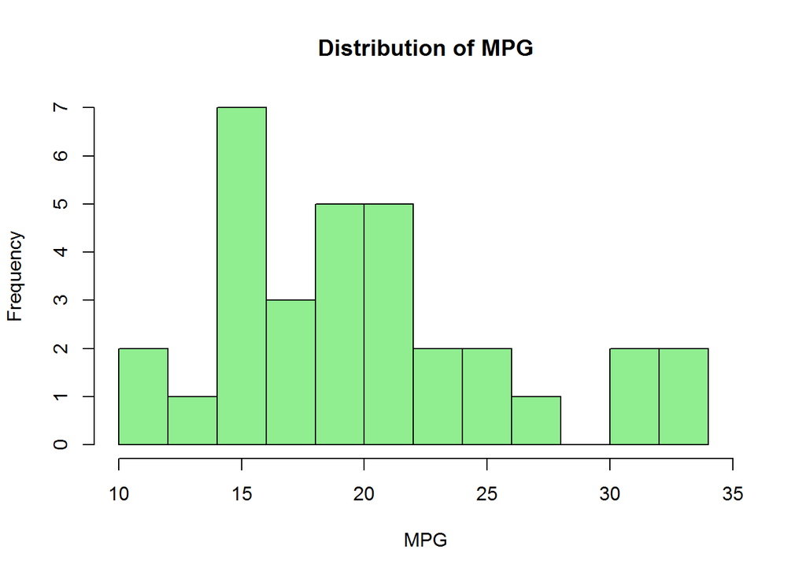

```r
hist(mtcars$mpg, breaks = 15, xlab = "MPG", main = "Distribution of MPG", col = "lightgreen", xlim = c(10,35))
```

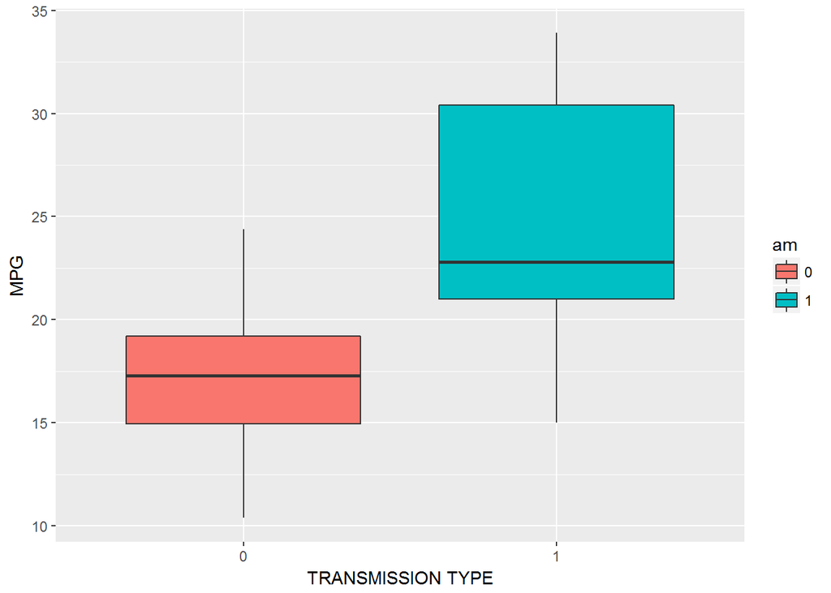

```r
plot <- ggplot(mtcars, aes(x = am, y = mpg)) + geom_boxplot(aes(fill = am)) + labs(x = "TRANSMISSION TYPE", y = "MPG")
plot
```

```r
t.test(mpg ~ am, data = mtcars)
```

```
##
##  Welch Two Sample t-test
##
## data:  mpg by am
## t = -3.7671, df = 18.332, p-value = 0.001374
## alternative hypothesis: true difference in means is not equal to 0
## 95 percent confidence interval:
##  -11.280194  -3.209684
## sample estimates:
## mean in group 0 mean in group 1
##        17.14737        24.39231
```

In addition, according to the above box plot, automatic transmissions have lower MPG compared to manual transmission cars. Above t-test also confirms this finding since the p-value is below 0.05 and confidence interval is entirely below zero. Therefore, we can conclude that manual transmission cars have better fuel efficiency than cars with automatic transmissions. In the next section, we will perform regression analysis to see if that is in fact the case.

### Regression Analyses

In this part, we use regression analysis to see the relation between transmission type and MPG. First of all, we use only the transmission type to predict the MPG:

```r
fit.am <- lm(mpg ~ am, data = mtcars)
summary(fit.am)
```

```
##
## Call:
## lm(formula = mpg ~ am, data = mtcars)
##
## Residuals:
##     Min      1Q  Median      3Q     Max
## -9.3923 -3.0923 -0.2974  3.2439  9.5077
##
## Coefficients:
##             Estimate Std. Error t value Pr(>|t|)
## (Intercept)   17.147      1.125  15.247 1.13e-15 ***
## am1            7.245      1.764   4.106 0.000285 ***
## ---
## Signif. codes:  0 '***' 0.001 '**' 0.01 '*' 0.05 '.' 0.1 ' ' 1
##
## Residual standard error: 4.902 on 30 degrees of freedom
## Multiple R-squared:  0.3598, Adjusted R-squared:  0.3385
## F-statistic: 16.86 on 1 and 30 DF,  p-value: 0.000285
```

As you can see, transmission type is a significant factor in the model and manual transmission causes a 7.245 increase in MPG. However, adjusted R-square is 0.3385 which means that only 33.85% of the variation in MPG is explained by the transmission type. Now let’s use all available variables and see if we can predict the change in MPG variable better:

```r
fit.all <- lm(mpg ~ ., data = mtcars)
summary(fit.all)
```

```
##
## Call:
## lm(formula = mpg ~ ., data = mtcars)
##
## Residuals:
##     Min      1Q  Median      3Q     Max
## -3.5087 -1.3584 -0.0948  0.7745  4.6251
##
## Coefficients:
##             Estimate Std. Error t value Pr(>|t|)
## (Intercept) 23.87913   20.06582   1.190   0.2525
## cyl6        -2.64870    3.04089  -0.871   0.3975
## cyl8        -0.33616    7.15954  -0.047   0.9632
## disp         0.03555    0.03190   1.114   0.2827
## hp          -0.07051    0.03943  -1.788   0.0939 .
## drat         1.18283    2.48348   0.476   0.6407
## wt          -4.52978    2.53875  -1.784   0.0946 .
## qsec         0.36784    0.93540   0.393   0.6997
## vs1          1.93085    2.87126   0.672   0.5115
## am1          1.21212    3.21355   0.377   0.7113
## gear4        1.11435    3.79952   0.293   0.7733
## gear5        2.52840    3.73636   0.677   0.5089
## carb2       -0.97935    2.31797  -0.423   0.6787
## carb3        2.99964    4.29355   0.699   0.4955
## carb4        1.09142    4.44962   0.245   0.8096
## carb6        4.47757    6.38406   0.701   0.4938
## carb8        7.25041    8.36057   0.867   0.3995
## ---
## Signif. codes:  0 '***' 0.001 '**' 0.01 '*' 0.05 '.' 0.1 ' ' 1
##
## Residual standard error: 2.833 on 15 degrees of freedom
## Multiple R-squared:  0.8931, Adjusted R-squared:  0.779
## F-statistic:  7.83 on 16 and 15 DF,  p-value: 0.000124
```

When we use all the available variables to create a model, we can explain 77.9% of the variation in MPG. However, rather than using every variable provided in a dataset, sometimes we can predict a variable better with a subset of variables. So, in the next step we try to find the best linear regression model that can predict MPG:

```r
fit.best <- step(fit.all, direction="both", trace=0)
summary(fit.best)
```

```
##
## Call:
## lm(formula = mpg ~ cyl + hp + wt + am, data = mtcars)
##
## Residuals:
##     Min      1Q  Median      3Q     Max
## -3.9387 -1.2560 -0.4013  1.1253  5.0513
##
## Coefficients:
##             Estimate Std. Error t value Pr(>|t|)
## (Intercept) 33.70832    2.60489  12.940 7.73e-13 ***
## cyl6        -3.03134    1.40728  -2.154  0.04068 *
## cyl8        -2.16368    2.28425  -0.947  0.35225
## hp          -0.03211    0.01369  -2.345  0.02693 *
## wt          -2.49683    0.88559  -2.819  0.00908 **
## am1          1.80921    1.39630   1.296  0.20646
## ---
## Signif. codes:  0 '***' 0.001 '**' 0.01 '*' 0.05 '.' 0.1 ' ' 1
##
## Residual standard error: 2.41 on 26 degrees of freedom
## Multiple R-squared:  0.8659, Adjusted R-squared:  0.8401
## F-statistic: 33.57 on 5 and 26 DF,  p-value: 1.506e-10
```

As you can see, using only four variables (cyl, hp, wt, and am) we can explain 84.01% of the variation in MPG which is more than the previous model where we used all variables.

```r
t <- data.frame("Model" = c("Transmission Type", "All Variables", "Best Model", "Transmission Type", "All Variables", "Best Model"), "R.Squared" = c(summary(fit.am)$r.squared, summary(fit.all)$r.squared, summary(fit.best)$r.squared, summary(fit.am)$adj.r.squared, summary(fit.all)$adj.r.squared, summary(fit.best)$adj.r.squared), "Type" = c("R-squared","R-squared","R-squared","Adjusted.R-squared","Adjusted.R-squared","Adjusted.R-squared"))
t$Model <- factor(t$Model, levels=c("Transmission Type", "All Variables", "Best Model"))

t1 <- data.frame("Model" = c("Transmission Type", "All Variables", "Best Model"), "Sigma" = c(summary(fit.am)$sigma, summary(fit.all)$sigma, summary(fit.best)$sigma))
t1$Model <- factor(t1$Model, levels=c("Transmission Type", "All Variables", "Best Model"))
```

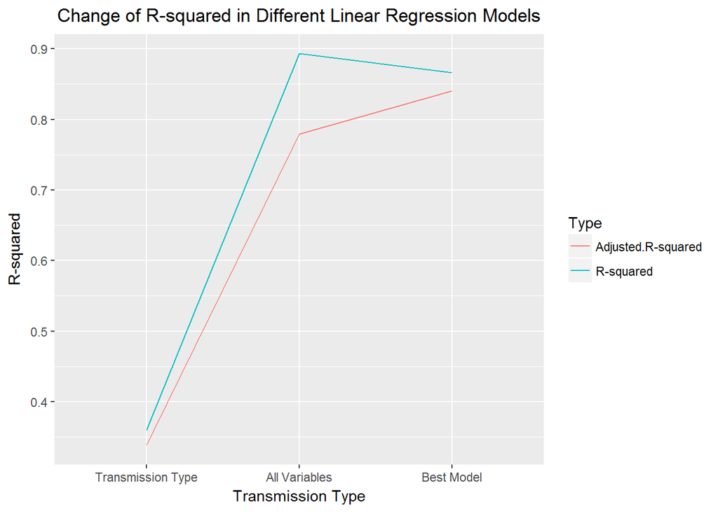

```r
plot <- ggplot(t, aes(x = Model, y = R.Squared)) +  geom_line(aes(colour = Type, group = Type)) + xlab("Transmission Type") + ylab("R-squared") + ggtitle("Change of R-squared in Different Linear Regression Models") + theme(plot.title = element_text(hjust = 0.5))
plot
```

As you can see in the above plot, even though we observe increasing adjusted R-squared as we modify our models, R-squared in the third model is less than the second model. When comparing different models, we use adjusted R-squared measures rather than R-squared because that has been adjusted for the number of predictors in the model.

Furthermore, you can see the change in residual standard error in the below plot. We observe the minimum residual standard error in the third model, so we select the third model as our final model.

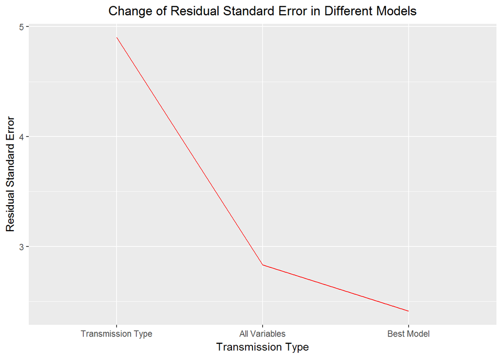

```r
plot <- ggplot(t1, aes(x = Model, y = Sigma)) +  geom_line(aes(group = 1), col = "red") + xlab("Transmission Type") + ylab("Residual Standard Error") + ggtitle("Change of Residual Standard Error in Different Models") + theme(plot.title = element_text(hjust = 0.5))
plot
```